# Correlation & Stratification

## Loading data

Lets load the Golton Families data

```r
library(HistData)
library(tidyverse)
data("GaltonFamilies")
str(GaltonFamilies)
```

```
'data.frame':   934 obs. of  8 variables:
 $ family         : Factor w/ 205 levels "001","002","003",..: 1 1 1 1 2 2 2 2 3 3 ...
 $ father         : num  78.5 78.5 78.5 78.5 75.5 75.5 75.5 75.5 75 75 ...
 $ mother         : num  67 67 67 67 66.5 66.5 66.5 66.5 64 64 ...
 $ midparentHeight: num  75.4 75.4 75.4 75.4 73.7 ...
 $ children       : int  4 4 4 4 4 4 4 4 2 2 ...
 $ childNum       : int  1 2 3 4 1 2 3 4 1 2 ...
 $ gender         : Factor w/ 2 levels "female","male": 2 1 1 1 2 2 1 1 2 1 ...
 $ childHeight    : num  73.2 69.2 69 69 73.5 72.5 65.5 65.5 71 68 ...
```

## Filter Data

Create a subset with -> Only first sons ( gender = “male”) ( childNum = 1) -> Only Father and child’s height

```r
 galton_heights <- GaltonFamilies %>% filter(childNum == 1 & gender == "male") %>% select(father, childHeight) %>% rename(son = childHeight)
```

Lets plot and see if there are related

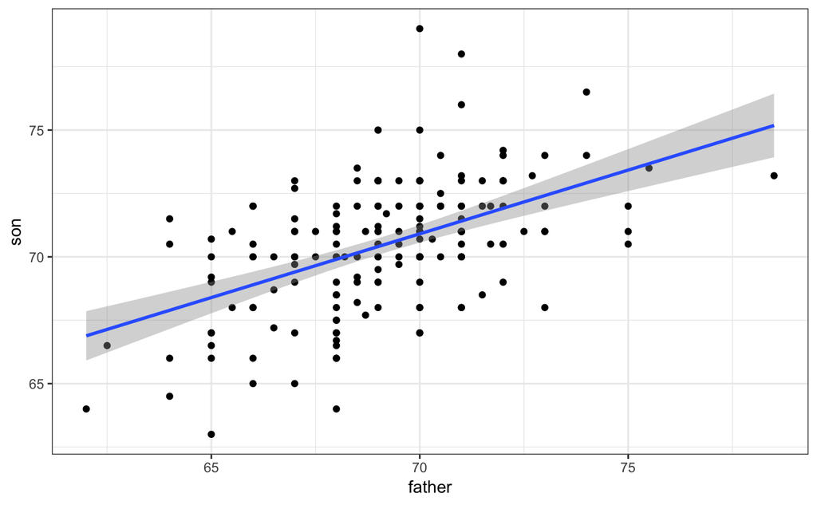

```r
library(dslabs)
ds_theme_set()
galton_heights %>% ggplot(aes(father, son)) +
  geom_point() +
  stat_smooth(method = "lm")
```

```r
NA
```

## Compute Correlation

Since the data is normal distributed lets find the mean & SD

```r
galton_heights %>% summarize(mean(father), sd(father), mean(son), sd(son), cor(father, son))
```

| mean(father) | sd(father) | mean(son) | sd(son) | cor(father, son) |
| --- | --- | --- | --- | --- |
| 69.09888 | 2.546555 | 70.45475 | 2.557061 | 0.5007248 |

Lets compute correlation through its formula

```r
mu_f <- mean(galton_heights$father)
s_f <- sd(galton_heights$father)
mu_s <- mean(galton_heights$son)
s_s <- sd(galton_heights$son)
# Lets compute (1) the father's height distance from mean (2) sons height distance from mean (3) product of these
gh <- galton_heights %>% mutate(df = (father - mu_f) / s_f, ds = (son - mu_s) / s_s ) %>% mutate(corx = df * ds)
# correlation = sum of the product by count of the product
gh %>% summarize(sum(corx)) / count(gh)
```

| sum(corx) |
| --- |
| 0.4979274 |

We could as well rewrite the entire above code in the below one line

```r
# Lets compute (1) the father's height distance from mean (2) sons height distance from mean (3) product of these
galton_heights %>% mutate(df = (father - mean(father)) / sd(father), ds = (son - mean(son)) / sd(son) ) %>% mutate(corx = df * ds) %>% summarize(sum(corx)) / count(galton_heights)
```

| sum(corx) |
| --- |
| 0.4979274 |

## Stratification

### Problem:

Find height of son from fathers height ( father’s height = 72 )

### 1. Simple prediction

Take the mean irrespective of father’s height

```r
mean(galton_heights$son)
```

```
[1] 70.45475
```

### 2. Using correlation

Given father’s height is 72 lets figure out how far is he from mean apply the same to Son.

Mean:

```r
mean(galton_heights$father)
```

```
[1] 69.09888
```

SD:

```r
sd(galton_heights$father)
```

```
[1] 2.546555
```

Distance from mean in terms of standard deviation:

```r
dmf = (72 - mean(galton_heights$father)) / sd(galton_heights$father)
dmf
```

```
[1] 1.139232
```

Calculating sons height

```r
dmf * sd(galton_heights$son) + mean(galton_heights$son)
```

```
[1] 73.36783
```

This is an over estimate.

### 3. Stratification

Round off the heights of father to nearest number and take the average from there.

Below chart shows the rounded fathers heights against sons height

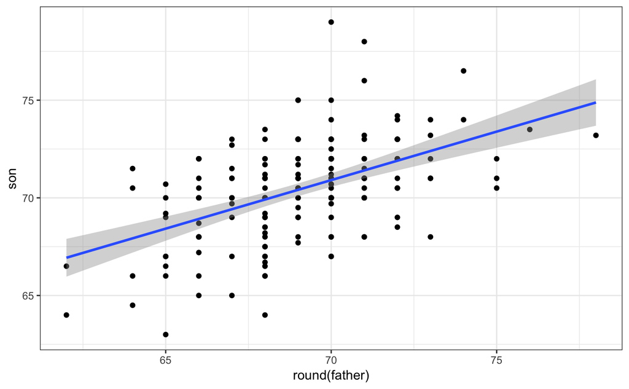

```r
ds_theme_set()
galton_heights %>% ggplot(aes(round(father), son)) +
  geom_point() +
  stat_smooth(method = "lm")
```

```r
galton_heights %>% mutate(rf = round(father)) %>% filter(rf == 72) %>% summarize(mean(son))
```

| mean(son) |
| --- |
| 71.83571 |

### Plots to view stratified data

#### Box plot to view the distribution of sons height data at rounded of height

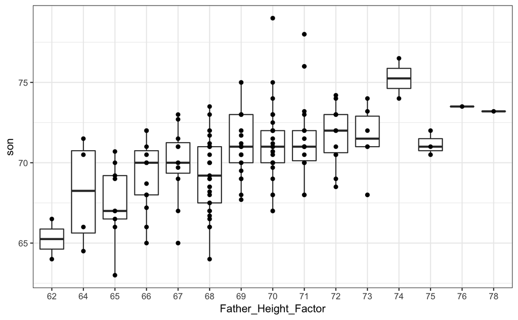

```r
galton_heights %>% mutate(Father_Height_Factor = factor(round(father))) %>% ggplot(aes(Father_Height_Factor, son)) +
  geom_boxplot() +
  geom_point()
```

#### Plot of fathers rounded height vs. sons height mean

```r
galton_heights %>% mutate(father = round(father)) %>% group_by(father) %>% summarize(mean(son))
```

| father | mean(son) |
| --- | --- |
| 62 | 65.25000 |
| 64 | 68.12500 |
| 65 | 67.60000 |
| 66 | 69.22667 |
| 67 | 69.99091 |
| 68 | 69.20968 |
| 69 | 71.23333 |
| 70 | 71.15263 |
| 71 | 71.51111 |
| 72 | 71.83571 |

[output cut: 5 more lines]

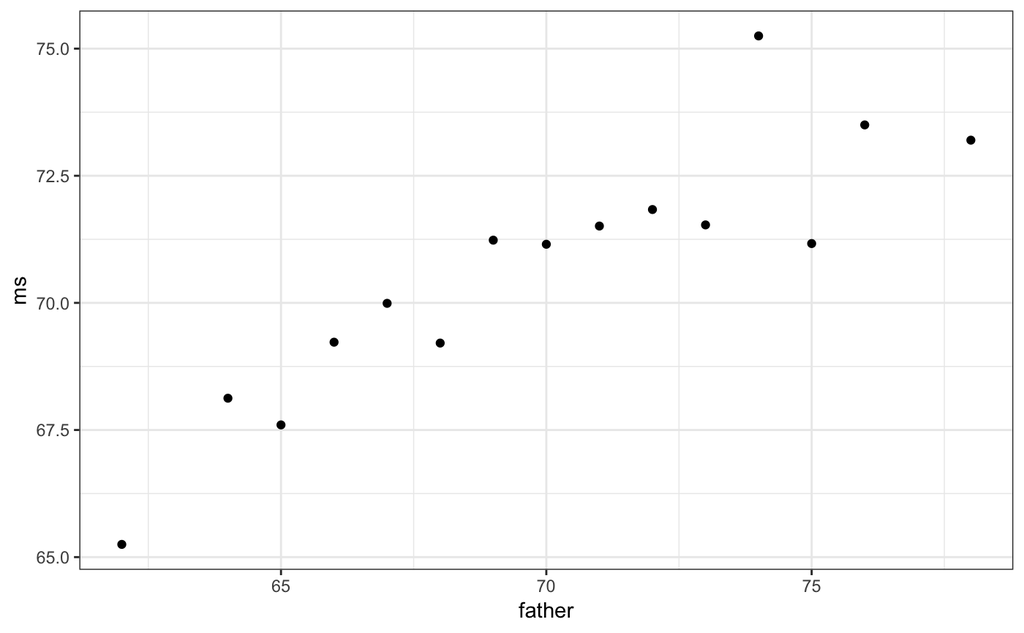

```r
galton_heights %>% mutate(father = round(father)) %>% group_by(father) %>% summarize(ms = mean(son)) %>%
  ggplot(aes(father, ms)) +
  geom_point()
```

#### Draw the scaled graph with slope

Find the correlation

```r
r = cor(galton_heights$father, galton_heights$son)
r
```

```
[1] 0.5007248
```

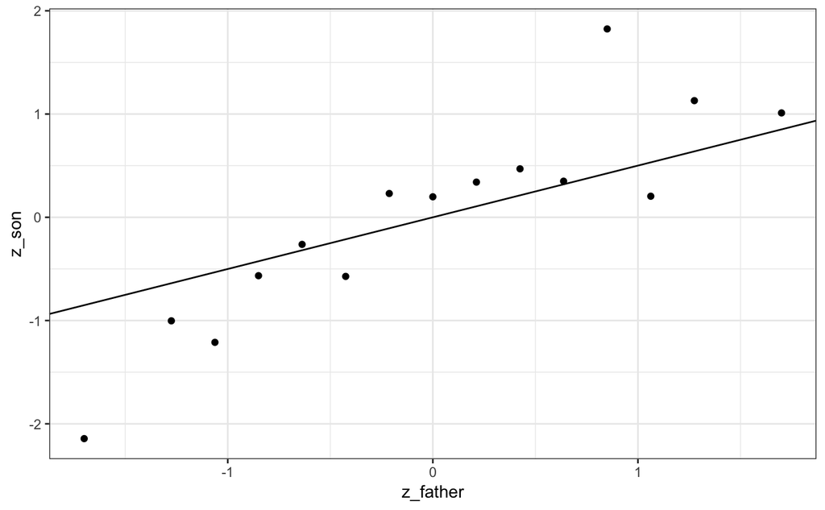

```r
require(stats)
galton_heights %>% mutate(father = round(father)) %>% group_by(father) %>% summarize(son = mean(son)) %>%
  mutate(z_father = scale(father), z_son = scale(son)) %>%
  ggplot(aes(z_father, z_son)) +
  geom_point() +
  geom_abline(slope = r, intercept = 0)
```

### Understanding scale function

Scale documentation says: “scale is generic function whose default method centers and/or scales the columns of a numeric matrix.”

```r
galton_heights %>% mutate(ss = scale(son), sf = scale(father), zf = (father - mu_f) / sd_f, zs = (son - mu_s) / sd_s )
```

[output not shown]

### Add the regression line to the father and son hights chart

Slope = Corr(x, y) * SD (y) / SD (x) Slope = Corr(Father, Son) * SD(son) / SD(father)

Intercept = mean(y) - slope * mean(x)

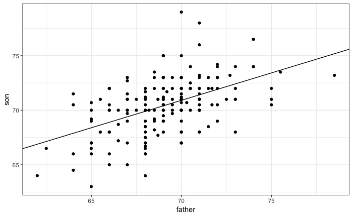

```r
mu_f <- mean(galton_heights$father)
sd_f <- sd(galton_heights$father)
mu_s <- mean(galton_heights$son)
sd_s <- sd(galton_heights$son)
r <- cor(galton_heights$father, galton_heights$son)
m <- r * s_s / s_f
b <- mu_s - m * mu_f
galton_heights %>% ggplot(aes(father, son)) +
  geom_point() +
  geom_abline(slope = m, intercept = b)
```

## Bivariate normal distribution

Two variables are said to be in bivariate normal distribution if for each grouping of X, Y is in normal distribution.

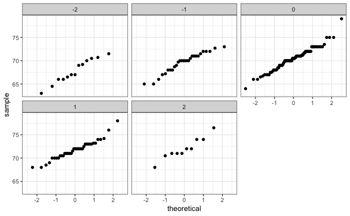

```r
galton_heights %>% mutate(z_father = round( (father - mu_f) / sd_f ) ) %>%
  filter(z_father %in% -2:2) %>%
  ggplot() +
  stat_qq(aes(sample = son)) +
  facet_wrap(~z_father)
```

## Linear Models

```r
summary(mod)
```

```
Call:
lm(formula = son ~ father, data = galton_heights)

Residuals:
    Min      1Q  Median      3Q     Max
-5.9022 -1.4050  0.0922  1.3422  8.0922

Coefficients:
            Estimate Std. Error t value Pr(>|t|)
(Intercept) 35.71249    4.51737   7.906 2.75e-13 ***
father       0.50279    0.06533   7.696 9.47e-13 ***
---
Signif. codes:  0 ‘***’ 0.001 ‘**’ 0.01 ‘*’ 0.05 ‘.’ 0.1 ‘ ’ 1

Residual standard error: 2.22 on 177 degrees of freedom
Multiple R-squared:  0.2507,    Adjusted R-squared:  0.2465
F-statistic: 59.23 on 1 and 177 DF,  p-value: 9.473e-13
```

## Least Squares Estimates (LSE)

Find least value of Beta1 where Beta0 = 36

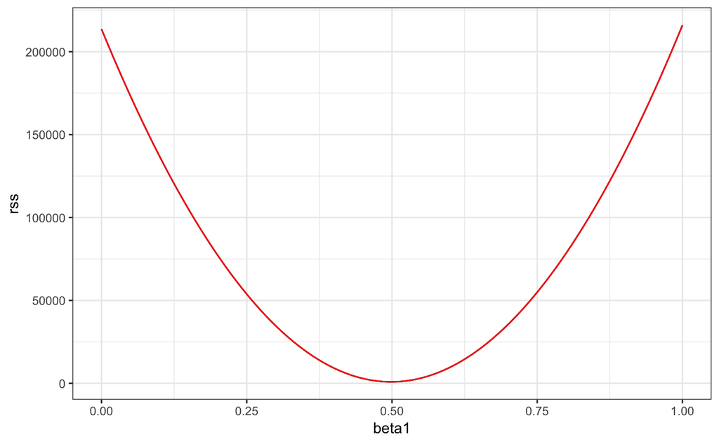

### LSE are random variables

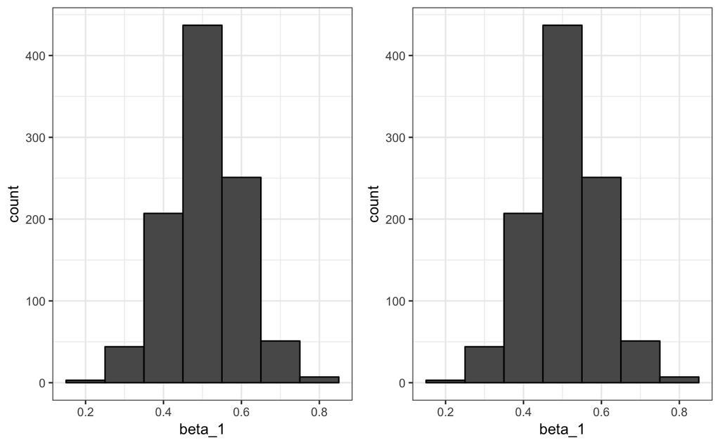

### Plots to predict the sons height

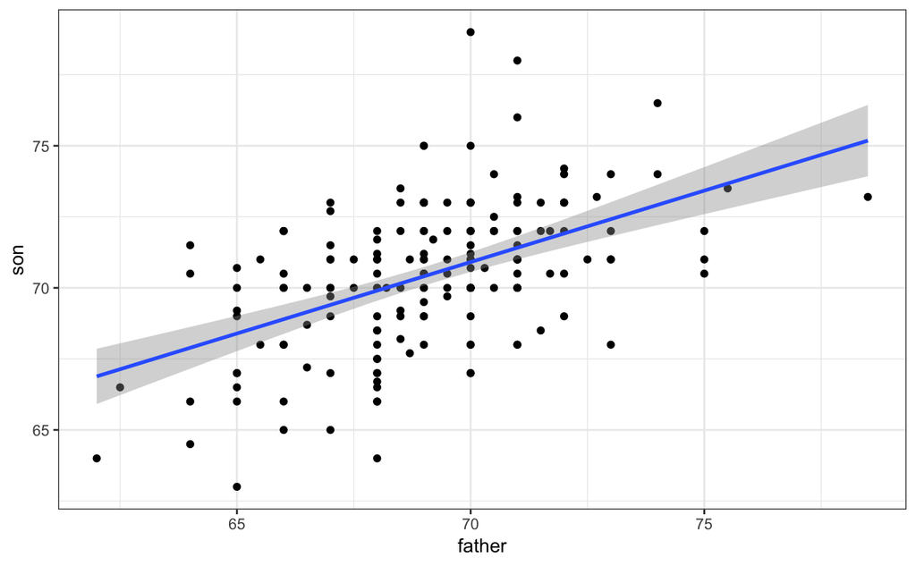

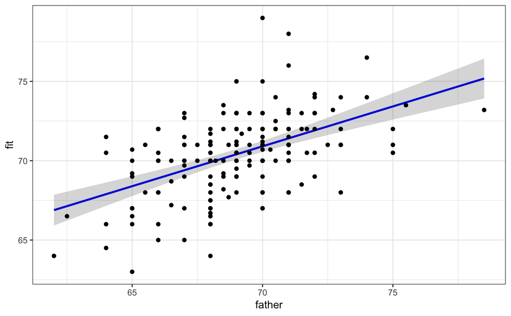